# Explore velocities on subset of tissue clusters for Pijuan-Sala data

This notebook is about exploring the. velocities derived from the subset.

```python
import scanpy as sc
import scvelo as scv
from pathlib import Path
import matplotlib.pyplot as plt
import pandas as pd
import numpy as np
import rna_velo_pred.utils as ut
import rna_velo_pred.info_het as ih
%matplotlib inline
```

```python
figures_dir = Path().cwd() / "report3"
data_root = Path("/disk/scratch/data/rna-velocity-prediction/pijuansala")
```

```python
sc.settings.verbosity = 3             # verbosity: errors (0), warnings (1), info (2), hints (3)
sc.logging.print_header()
sc.settings.set_figure_params(dpi=100, facecolor='white')
sc.settings.figdir=figures_dir
scv.settings.figdir=str(figures_dir)
```

```
scanpy==1.7.1 anndata==0.7.5 umap==0.5.1 numpy==1.19.5 scipy==1.5.4 pandas==1.1.5 scikit-learn==0.24.1 statsmodels==0.12.2 python-igraph==0.9.1 leidenalg==0.8.3
```

## Set up the stage names

The dataset includes 'E6.5', 'E6.75', 'E7.0', 'E7.25', 'E7.5', 'E7.75', 'E8.0', 'E8.25', 'E8.5' but this is often too big for memory so try a smaller set.

```python
#stage_names = ut.PIJUAN_STAGES
stage_names = ['E6.5', 'E6.75', 'E7.0', 'E7.25', 'E7.5']
stage_names
```

```
['E6.5', 'E6.75', 'E7.0', 'E7.25', 'E7.5']
```

## Read in gene names

They are in genes.tsv and **should** be in the original AnnData!

```python
genes_filename = data_root / "atlas" / "genes.tsv"
genes = pd.read_csv(genes_filename, sep="\s+", header=None, names=["gene_id", "gene_name"], index_col="gene_id")
genes.head()
```

| gene_id | gene_name |
| --- | --- |
| ENSMUSG00000051951 | Xkr4 |
| ENSMUSG00000089699 | Gm1992 |
| ENSMUSG00000102343 | Gm37381 |
| ENSMUSG00000025900 | Rp1 |
| ENSMUSG00000025902 | Sox17 |

## Create an array of filtered subsetted stage data

Also want to rename the var index following [this](https://scanpy.discourse.group/t/how-to-rename-genes-in-an-anndata-object/254) discussion.

```python
adata_by_stage = []
for stage_index, stage_name in enumerate(stage_names):
    adata_at_stage = scv.read(data_root / "subset" / f"adata_{stage_name}.h5ad")
    adata_at_stage.var_names = adata_at_stage.var.gene_name
    adata_by_stage.append(adata_at_stage)
```

## Try a single stage

The is the most fine-grained resolution showing single-cell level with each arrow showing the direction and speed of movement for an individual cell.

```
computing velocity embedding
    finished (0:00:00) --> added
    'velocity_umap', embedded velocity vectors (adata.obsm)
saving figure to file /afs/inf.ed.ac.uk/user/s21/s2125151/code/src/git.ecdf.ed.ac.uk/s2042526/rna-velocity-prediction/notebooks/report3/scvelo_pij_subset_umap_E6.5_velo.png
```

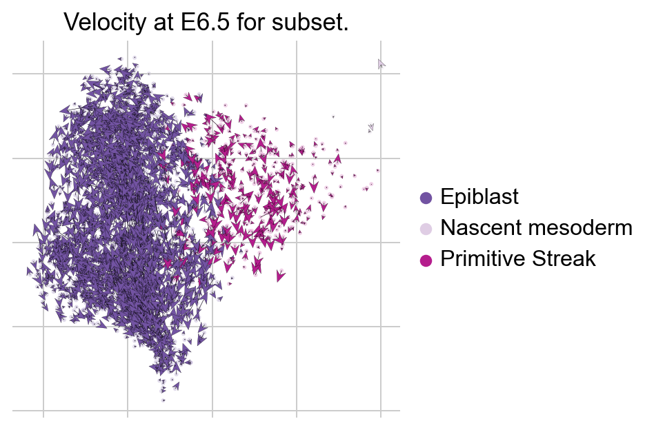

```python
stage= 0
adata_for_stage = adata_by_stage[stage]
scv.pl.velocity_embedding(adata_for_stage, color='celltype', basis="umap", \
                          title=f"Velocity at {stage_names[stage]} for subset.",
                          legend_loc="right margin", save=f"pij_subset_umap_{stage_names[stage]}_velo.png",
                          arrow_length=5, arrow_size=5, dpi=180)
```

## Experimental: expression by celltype

See https://github.com/theislab/scanpy/issues/955 for example and discussion.

Note: This doesn't seem to work for velocity projections. A list works but not a list of lists.

```
saving figure to file /afs/inf.ed.ac.uk/user/s21/s2125151/code/src/git.ecdf.ed.ac.uk/s2042526/rna-velocity-prediction/notebooks/report3/scvelo_pij_subset_celltypeE6.5.png
```

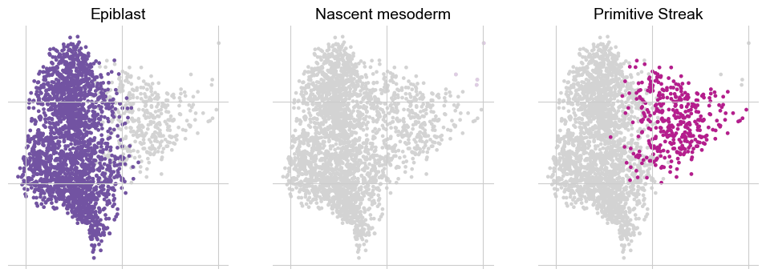

```python
stage= 0
adata_for_stage = adata_by_stage[stage]
scv.pl.scatter(adata_for_stage,
               groups=[[c] for c in adata_for_stage.obs['celltype'].cat.categories],
               color='celltype', save=f"pij_subset_celltype{stage_names[stage]}.png",
               ncols=4)
```

## Important genes

We can test which genes have celltype-specific differential velocity expression, being significantly higher/lower compared to the remaining population. `min_corr` restricst the test to those with a minimum spearman correlation.

From [this discussion](https://github.com/theislab/scvelo/issues/210) maybe worth trying `scv.tl.rank_dynamical_genes` which orders genes by their likelihood from the dynamical model. See [here](https://scvelo.readthedocs.io/DynamicalModeling.html#Cluster-specific-top-likelihood-genes) for some more details.

```python
stage= 0
adata_for_stage = adata_by_stage[stage]
scv.tl.rank_velocity_genes(adata_for_stage, groupby='celltype', min_corr=.3)

df = scv.DataFrame(adata_for_stage.uns['rank_velocity_genes']['names'])
df.head()
```

```
ranking velocity genes
    finished (0:00:09) --> added
    'rank_velocity_genes', sorted scores by group ids (adata.uns)
    'spearmans_score', spearmans correlation scores (adata.var)
```

|  | Epiblast | Nascent mesoderm | Primitive Streak |
| --- | --- | --- | --- |
| 0 | Vmp1 | Fus | Tcf7l1 |
| 1 | Atp5a1 | Rpl9 | Rpl13a |
| 2 | Arl6ip4 | Arl6ip4 | Fus |
| 3 | Gnai2 | Rps11 | Gnl3 |
| 4 | Naa10 | Tcf7l1 | Rps11 |

## Phase diagrams - Interpreting the velocities

See [interpreting velocities](https://scvelo.readthedocs.io/VelocityBasics.html#Interprete-the-velocities) for this section for advice. The key seems to be [this animation](https://user-images.githubusercontent.com/31883718/80227452-eb822480-864d-11ea-9399-56886c5e2785.gif) which shows the on (induction) and off (repression) phases. The upper curve is "on" and the lower curve is "off". The line in the middle represents the steady state.

RNA velocity for a particular gene is determined as the residual so how much an observation deviates from the steady-state line. Positive velocity means the gene is up-regulated so more unspliced the spliced compared to the steady state and the converse for down regulated genes.

```
saving figure to file /afs/inf.ed.ac.uk/user/s21/s2125151/code/src/git.ecdf.ed.ac.uk/s2042526/rna-velocity-prediction/notebooks/report3/scvelo_pij_subset_ps_genesE6.5.png
```

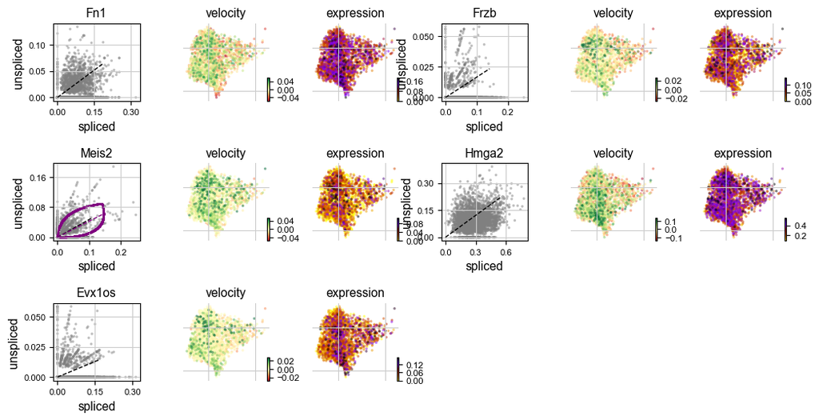

```python
stage= 0
adata_for_stage = adata_by_stage[stage]
scv.pl.velocity(adata_for_stage, ["Fn1", "Frzb", "Meis2", "Hmga2", "Evx1os"], ncols=2,
                save=f"pij_subset_ps_genes{stage_names[stage]}.png")
```

```python
adata_for_stage
```

```
AnnData object with n_obs × n_vars = 2661 × 29452
    obs: 'barcode', 'sample', 'stage', 'sequencing.batch', 'theiler', 'doub.density', 'cluster', 'cluster.sub', 'cluster.stage', 'cluster.theiler', 'celltype', 'colour', 'umapX', 'umapY', 'haem_gephiX', 'haem_gephiY', 'haem_subclust', 'endo_gephiX', 'endo_gephiY', 'endo_trajectoryName', 'endo_trajec…
    var: 'gene_name', 'gene_count_corr', 'velocity_gamma', 'velocity_r2', 'velocity_genes', 'fit_alpha', 'fit_beta', 'fit_gamma', 'fit_t_', 'fit_scaling', 'fit_std_u', 'fit_std_s', 'fit_likelihood', 'fit_u0', 'fit_s0', 'fit_pval_steady', 'fit_steady_u', 'fit_steady_s', 'fit_variance', 'fit_alignment…
    uns: 'celltype_colors', 'neighbors', 'pca', 'recover_dynamics', 'velocity_graph', 'velocity_graph_neg', 'velocity_params', 'rank_velocity_genes'
    obsm: 'X_pca', 'X_umap', 'velocity_pca', 'velocity_umap'
    varm: 'PCs', 'loss'
    layers: 'Ms', 'Mu', 'ambiguous', 'fit_t', 'fit_tau', 'fit_tau_', 'spliced', 'unspliced', 'variance_velocity', 'velocity'
    obsp: 'connectivities', 'distances'
```

## Phase diagrams

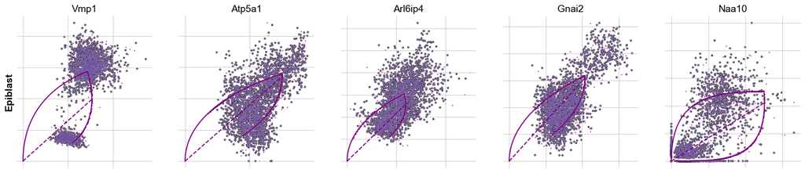

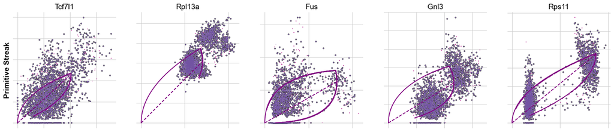

```python
stage= 0
adata_for_stage = adata_by_stage[stage]
kwargs = dict(frameon=False, size=10, linewidth=1.5, color="celltype",
              add_outline="Epiblast, 'Primitive Streak'")

scv.pl.scatter(adata_for_stage, df['Epiblast'][:5], ylabel='Epiblast', **kwargs)
scv.pl.scatter(adata_for_stage, df['Primitive Streak'][:5], ylabel='Primitive Streak', **kwargs)
```

## Kinetic rate parameters by gene

See [here](https://scvelo.readthedocs.io/DynamicalModeling.html#Kinetic-rate-paramters) for more details.

```
Rate parameters for stage=E6.5
```

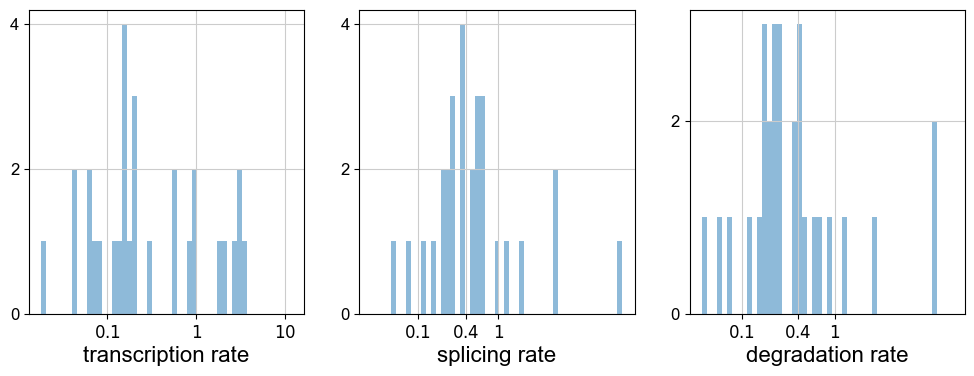

```
Rate parameters for stage=E6.75
```

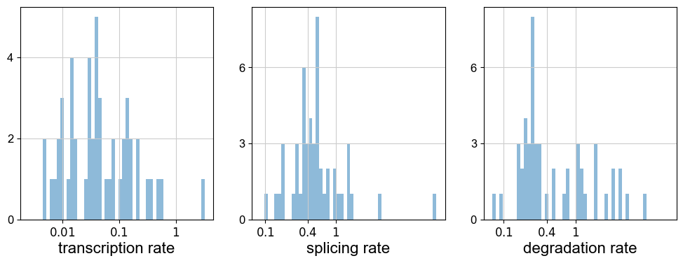

```
Rate parameters for stage=E7.0
```

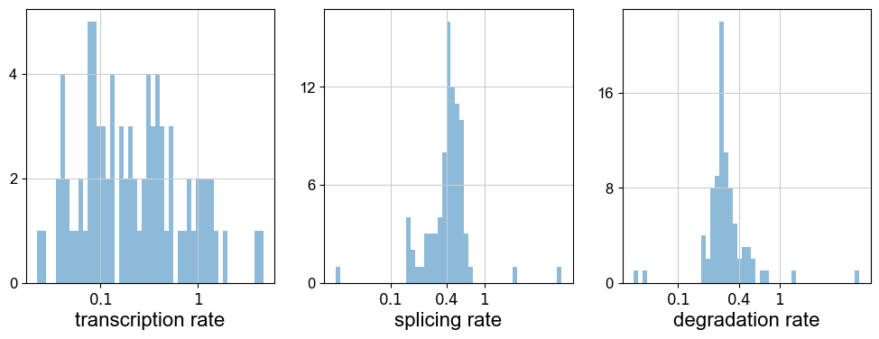

```
Rate parameters for stage=E7.25
```

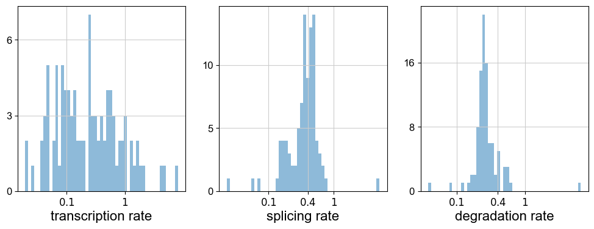

```
Rate parameters for stage=E7.5
```

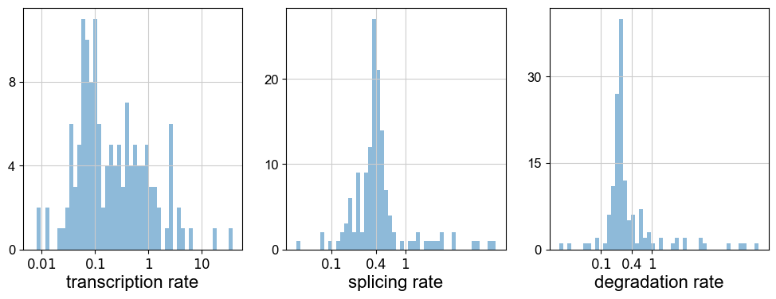

```python
for stage_index, stage_name in enumerate(stage_names):
    adata_for_stage = adata_by_stage[stage_index]

    df = adata_for_stage.var
    df = df[(df['fit_likelihood'] > .1) & df['velocity_genes'] == True]

    kwargs = dict(xscale='log', fontsize=16)
    with scv.GridSpec(ncols=3) as pl:
        print(f"Rate parameters for stage={stage_name}")
        pl.hist(df['fit_alpha'], xlabel='transcription rate', **kwargs)
        pl.hist(df['fit_beta'] * df['fit_scaling'], xlabel='splicing rate', xticks=[.1, .4, 1], **kwargs)
        pl.hist(df['fit_gamma'], xlabel='degradation rate', xticks=[.1, .4, 1], **kwargs)
```

## Velocities in cycling progenitors

See [this section](https://scvelo.readthedocs.io/VelocityBasics.html#Interprete-the-velocities) for examples and [api](https://scvelo.readthedocs.io/scvelo.tl.score_genes_cell_cycle.html#scvelo.tl.score_genes_cell_cycle).

Identifies phases G1, S and G2M basedon list of genes in [Tirosh et al, 2015](https://doi.org/10.1126/science.aad0501).

```
computing score 'S_score'
    finished: added
    'S_score', score of gene set (adata.obs).
    292 total control genes are used. (0:00:00)
computing score 'G2M_score'
```

```
calculating cell cycle phase
```

```
    finished: added
    'G2M_score', score of gene set (adata.obs).
    250 total control genes are used. (0:00:00)
```

```
-->     'S_score' and 'G2M_score', scores of cell cycle phases (adata.obs)
saving figure to file /afs/inf.ed.ac.uk/user/s21/s2125151/code/src/git.ecdf.ed.ac.uk/s2042526/rna-velocity-prediction/notebooks/report3/scvelo_pij_subset_cell_cycle_E6.5.png
```

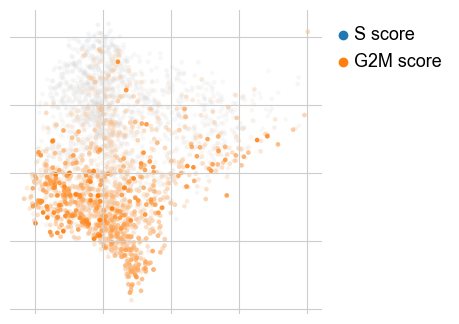

```python
#for stage_index, stage_name in enumerate(stage_names):
#    adata_for_stage = adata_by_stage[stage_index]
stage= 0
adata_for_stage = adata_by_stage[stage]
scv.tl.score_genes_cell_cycle(adata_for_stage)
scv.pl.scatter(adata_for_stage, color_gradients=['S_score', 'G2M_score'], smooth=True, perc=[5, 95],
              save=f"pij_subset_cell_cycle_{stage_names[stage]}.png")
```

## Speed and coherence

See [this section](https://scvelo.readthedocs.io/VelocityBasics.html#Speed-and-coherence) for details. The rate of differentiation is given by the length and the coherence of the filed provides a measure of confidence.

```
--> added 'velocity_length' (adata.obs)
--> added 'velocity_confidence' (adata.obs)
--> added 'velocity_confidence_transition' (adata.obs)
saving figure to file /afs/inf.ed.ac.uk/user/s21/s2125151/code/src/git.ecdf.ed.ac.uk/s2042526/rna-velocity-prediction/notebooks/report3/scvelo_pij_subset_speed_confidence_E6.5.png
```

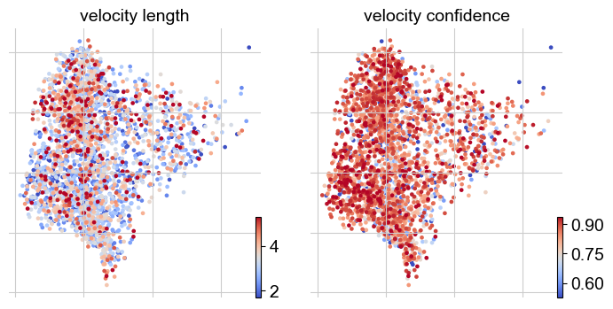

```python
stage= 0
adata_for_stage = adata_by_stage[stage]
scv.tl.velocity_confidence(adata_for_stage)
keys = 'velocity_length', 'velocity_confidence'
scv.pl.scatter(adata_for_stage, c=keys, cmap='coolwarm', perc=[5, 95],
              save=f"pij_subset_speed_confidence_{stage_names[stage]}.png")
```

```python
df = adata_for_stage.obs.groupby('celltype')[keys].mean().T
df.style.background_gradient(cmap='coolwarm', axis=1)
```

| celltype | Epiblast | Nascent mesoderm | Primitive Streak |
| --- | --- | --- | --- |
| velocity_length | 3.240953 | 2.677500 | 3.328740 |
| velocity_confidence | 0.801618 | 0.506867 | 0.802829 |

## Velocity graph and pseudotime

Detail from [here](https://scvelo.readthedocs.io/VelocityBasics.html#Velocity-graph-and-pseudotime). This visualizes the velocity-inferred cell-to-cell connections. The `threshold` limits the connections to high confidence ones.

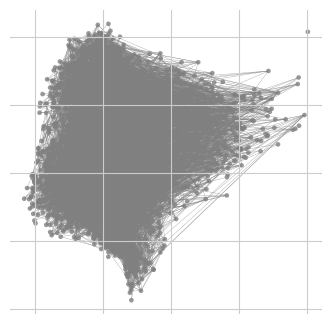

```python
stage= 0
adata_for_stage = adata_by_stage[stage]
scv.pl.velocity_graph(adata_for_stage, threshold=.9)
```

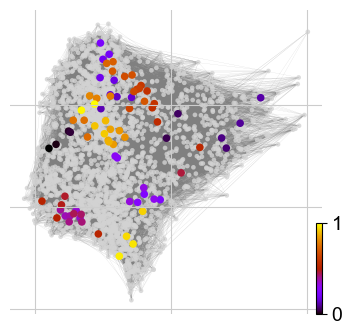

```python
x, y = scv.utils.get_cell_transitions(adata_for_stage, basis='umap', starting_cell=70)
ax = scv.pl.velocity_graph(adata_for_stage, c='lightgrey', edge_width=.05, show=False)
ax = scv.pl.scatter(adata_for_stage, x=x, y=y, s=120, c='ascending', cmap='gnuplot', ax=ax)
```

```
computing terminal states
    identified 2 regions of root cells and 1 region of end points .
    finished (0:00:00) --> added
    'root_cells', root cells of Markov diffusion process (adata.obs)
    'end_points', end points of Markov diffusion process (adata.obs)
```

```
Variable names are not unique. To make them unique, call `.var_names_make_unique`.
```

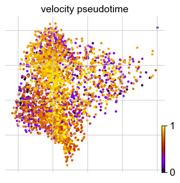

```python
scv.tl.velocity_pseudotime(adata_for_stage)
scv.pl.scatter(adata_for_stage, color='velocity_pseudotime', cmap='gnuplot')
```

## PAGA velocity graph

```python
# this is needed due to a current bug - bugfix is coming soon.
adata_for_stage.uns['neighbors']['distances'] = adata_for_stage.obsp['distances']
adata_for_stage.uns['neighbors']['connectivities'] = adata_for_stage.obsp['connectivities']

scv.tl.paga(adata_for_stage, groups='celltype')
df = scv.get_df(adata_for_stage, 'paga/transitions_confidence', precision=2).T
df.style.background_gradient(cmap='Blues').format('{:.2g}')
```

```
running PAGA using priors: ['velocity_pseudotime']
    finished (0:00:00) --> added
    'paga/connectivities', connectivities adjacency (adata.uns)
    'paga/connectivities_tree', connectivities subtree (adata.uns)
    'paga/transitions_confidence', velocity transitions (adata.uns)
```

|  | 0 | 1 | 2 |
| --- | --- | --- | --- |
| 0 | 0 | 0 | 0 |
| 1 | 0.067 | 0 | 0 |
| 2 | 0 | 0.029 | 0 |

```
WARNING: Invalid color key. Using grey instead.
saving figure to file /afs/inf.ed.ac.uk/user/s21/s2125151/code/src/git.ecdf.ed.ac.uk/s2042526/rna-velocity-prediction/notebooks/report3/scvelo_pij_subset_paga_E6.5.png
```

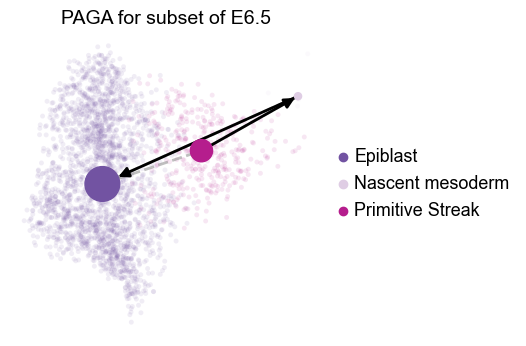

```python
scv.pl.paga(adata_for_stage, basis='umap', size=50, alpha=.1,
            min_edge_width=2, node_size_scale=1.5,
            save=f"pij_subset_paga_{stage_names[stage]}.png",
            title=f"PAGA for subset of {stage_names[stage]}")
```

## Splicing efficiency

See [here](https://github.com/theislab/scvelo/issues/173#issuecomment-602759851) for discussion of spiking efficieny in erythroid cells.

If we saw spiking effieicny change between cell types we might have an explanation but plots seems to show uniform distribution.

```
saving figure to file /afs/inf.ed.ac.uk/user/s21/s2125151/code/src/git.ecdf.ed.ac.uk/s2042526/rna-velocity-prediction/notebooks/report3/scvelo_pij_subset_splicing_efficiency_E6.5.png
```

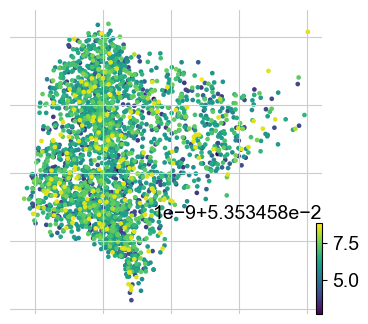

```python
stage= 0
adata_for_stage = adata_by_stage[stage]

counts_s = scv.utils.sum_var(adata_for_stage.layers['spliced'])
counts_u = scv.utils.sum_var(adata_for_stage.layers['unspliced'])
fractions_u = counts_u / (counts_s + counts_u)
scv.pl.scatter(adata_for_stage, color=fractions_u, smooth=True,
              save=f"pij_subset_splicing_efficiency_{stage_names[stage]}.png")
```

```python
print(f"min: {np.min(counts_s)}")
print(f"max: {np.max(counts_s)}")
print(counts_u.shape)
```

```
min: 8715.999999999996
max: 8716.000000000004
(2661,)
```